# Abstrakte Maschinen Ausarbeitung - 2025S

2025-06-22 14:44

# Aufbau von Interpretern

Aus dem Compilerbau-Skriptum:

> Ein **Interpreter** ist ein Programm, das Programme ausführen kann, die in seiner **Interpretersprache** I formuliert sind. Ein Interpreter verhält sich wie eine Maschine bzw. ein Prozessor. Man bezeichnet ihn daher auch als **virtuelle** oder **abstrakte Maschine**.

# Zwischencodes - Intermediate Language (IL)

Compiler und Interpreter laufen durch verschieden Phasen ("passes") (lexing, parsing, scope analysis, ...) - dabei wird üblicherweise der Code in verschiedene Datenstrukturen zum weiteren Verwenden gepackt (e.g. AST - abstract syntax **tree**). Da die semantic des ursprünglichen Codes (ein kontinuierlicher String) nicht verloren geht, kann man die neue Struktur als IL bezeichnen.

Meist bezeichnet man aber erst die letzteren Datenstrukturen als IL: Java Byte-Code, Microsoft IL, etc. Sprich: Von einer IL spricht man im Regelfall erst, sobald ein AST *linearisiert* wurde.

# Prozessorarchitekturen

Ein Prozessor "besteht" aus 2 verschiedenen Arten von Architekturen:

- **Befehlsarchitektur - instruction set architecture (ISA)**
- und die **Mikroarchitektur - microarchitecure (MiA)**

## ISA

References:

- [ISA - Wikipedia](https://en.wikipedia.org/wiki/Instruction_set_architecture)

Was die ISA macht steckt bereits im Namen: **instruction set** architecture. Hier wird also definiert, welche Instruktionen eine CPU versteht (im weiteren Sinne braucht die CPU dafür dann auch natürlich entsprechende Register, memory access, etc.), für RISC-V gibt es hier z. B. `addi ...` `li ...` `ret` (Das ist natürlich nur assembly-code, was die ISA "nichts" angeht, die ISA definiert hier wirklich nur die Befehle in bits)

Eine **RISC-V** CPU ist also jede beliebige CPU, welche die RISC-V ISA laut Spezifikation entsprechend implementiert. Das erklärt dann im weiteren auch leicht den Unterschied zwischen ISA und Microarchitecture.

### CISC, RISC, MISC, OISC, ...

References:

- [CISC - Wikipedia](https://en.wikipedia.org/wiki/Complex_instruction_set_computer)
- [RISC - Wikipedia](https://en.wikipedia.org/wiki/Reduced_instruction_set_computer)
- [MISC - Wikipedia](https://en.wikipedia.org/wiki/Minimal_instruction_set_computer)
- [OISC - Wikipedia](https://en.wikipedia.org/wiki/One-instruction_set_computer)

Es gibt in Bezug zur ISA hier verschiedene ISA-"Gruppen" ("Design Philosophien"), z. B.:

- CISC: Complex instruction set computer
  - variable Befehlslänge, komplexe Adressierungsarten, komplexe Befehle
  - Ein Befehl kann viele kleine Operationen ausführen (e.g. String compare)
  - Beispiele:
    - VAX
    - 68K
    - x86
- RISC: Reduced instruction set computer
  - fixe Befehlslänge, wenig Adressierungsarten, ein Speicherzugriff pro Befehl, einfache Befehle, viele Register
  - Ein Befehl führt einen kleinen Task aus (zb *nicht* zwei loads in einem Befehl)
  - Sagt nichts über die **Anzahl** der Befehle aus, RISCV hat trotzdem viele verschiedene Befehle
  - Beispiele:
    - MIPS
    - Precision Architecture
    - Sparc
    - ARM
    - PowerPC
    - Alpha
- MISC: Minimal instruction set computer
  - Nur sehr wenige Befehle, meist für Mikroprozessoren
  - Sind oft als Stack-Maschinen implementiert, dadurch können die Befehle deutlich simpler und kürzer gestaltet werden, da Operanden einfach vom Stack gelesen werden.
- OISC: One instruction set computer
  - Auch bekannt als **ULTIMATE REDUCED INSTRUCTION SET COMPUTER**
  - Nur eine einizige instruction (ja, nur eine)
  - Die fixe Befehlslänge ist damit natürlich trivial (daher auch U-RISC)
  - Siehe [Instruction-Types](https://en.wikipedia.org/wiki/One-instruction_set_computer#Instruction_types) für Beispiele von solchen instructions

## Microarchitecture

References:

- [Microarchitecture - Wikipedia](https://en.wikipedia.org/wiki/Microarchitecture)

(Hat nichts mit Mikroprozessoren zu tun)

Die Microarchitecture ist jetzt die **konkrete** Implementation einer ISA in einer CPU. Wie bereits gesagt, können mehrere verschiedene CPUs dieselbe ISA implementieren - es gibt viele RISC-V CPUs, diese sind aber natürlich nicht alle ident: Der Unterschied zwischen denen ist hierbei die unterschiedliche Microarchitecture.

Ein simples Beispiel für einen Unterschied in der Microarchitektur: Es gibt verschiedene implementationen für einen n-bit-Volladdierer (zb Ripple-Carry-Adder und Carry-lookahead-Adder). Da sich diese nur in der Performance (und Preis...) Unterscheiden, kann man diese beliebig austauschen. Die ISA bleibt also weiterhin gleich, aber die Microarchitektur hat sich geändert!

### (Moderne) Implementierungs-Techniken

References:

- [Microarchitecture#Microarchitectural_concepts - Wikipedia](https://en.wikipedia.org/wiki/Microarchitecture#Microarchitectural_concepts)

#### Pipelining

Wenn ein Befehl ausgeführt wird (zb `addi x5, 3`) werden viele Komponenten angesprochen. Ein Befehl muss zuerst geladen werden, dann decodiert, dann wird irgendwann die ALU angesprochen und irgendwann wird das Ergebnis irgendwo abgespeichert.

Pipelining nutzt dieses Verhalten aus: Während eine Berechnung gerade in der ALU (also nachdem der Befehl schon gefetched und decodiert wurde) stattfindet, kann der nächste Befehl bereits ausgeführt werden.

Oft nimmt man hier anfänglich zum Lernen des Konzepts diese Pipeline-Stages:

- Fetch: nächsten Befehl laden
- Decode: den Befehl decodieren
- Execute: den Befehl ausführen (meist über eine Berechnung in der ALU)
- Write back: Ergebnis returnen (entweder in ein Register oder Memory)

Pipelining hängt meist stark mit den anderen Techniken zusammen (zb result forwarding).

#### Superscalar

Pipelining erlaubt es, mehrere (potentiell voneinander abhängige) Instructions "verzahnt" auszuführen. Superscalar beschreibt hierbei ein **gleichzeitiges** Ausführen von Instructions (also z.B. zwei Instructions auf einmal fetchen). Dafür benötigt man zum einen natürlich entsprechend mehr Hardware, zum anderen aber auch ein handeln von dependencies zwischen diesen instructions.

#### Cache (decoded instruction cache)

Kleine caches auf der CPU für schnelleren Zugriff als auf main RAM, heutzutage meist ~2MB groß.

#### Result forwarding (bypass)

References:

- [Operand forwarding - Wikipedia](https://en.wikipedia.org/wiki/Operand_forwarding)

Theoretisch ist ein Ergebnis erst nach der `Write back` stage verfügbar. Allerdings "kennt" man das Ergebnis ja schon bereits nach der `Execute` stage, wo es in der ALU ausgerechnet wurde.

Damit eine instruction also nicht eine stage länger warten muss, kann (simplified) ein extra Wire in der CPU "platziert" werden, dass direkt vom output der ALU in den Input der ALU für die nächste Instruktion führt.

Result forwarding bezieht sich aber nicht nur auf die ALU / auf die Execute Stage, das ist implementationsabhängig.

#### Register renaming

References:

- [Register renaming - Wikipedia](https://en.wikipedia.org/wiki/Register_renaming)

Register können umbenannt werden um gewisse dependencies zwischen Instruktionen aufzulösen, was die Parallälität erhöht.

#### Branch prediction

Beim Pipelining ging es darum, den nächsten Befehl so früh es geht zu starten während der vorherige noch abgearbeitet wird. Ist der vorherige jetzt allerdings ein (conditional-)jump Befehl, stellt sich die Frage, welchen Befehl man nun fetchen soll.

Dafür gibt es branch prediction (mit verschiedenen, immer komplexer werdenden Implementationen), welche anhand von dem vergangenen Verhalten des Programms versuchen zu vorhersagen, welcher branch genommen wird.

Falls richtig geraten wurde, hat man einen performance benefit, falls falsch eben einen performance hit (falsche instruction muss geflushed werden und andere gestartet).

#### Reservation stations, history buffers, future files

References:

- [Reservation Station - Wikipedia](https://en.wikipedia.org/wiki/Reservation_station)
- [History buffer - Random Slides von einer Uni](https://course.ece.cmu.edu/~ece447/s15/lib/exe/fetch.php?media=onur-447-spring15-lecture11-precise-exceptions-afterlecture.ppt)
- [Future files - Random Slides von einer Uni](https://course.ece.cmu.edu/~ece447/s15/lib/exe/fetch.php?media=onur-447-spring15-lecture11-precise-exceptions-afterlecture.ppt)
- Reservation Station: Kümmert sich um das handeln von dependencies zwischen operands und checkt ob eine Komponente frei ist. Dadurch kann "buffered" gefetched und decoded werden und erst verzögert dann die execute stage ausgeführt werden. Das bedeutet dass das fetchen nicht stallen muss wenn eine Komponente gerade blockiert ist sondern so lange weiter fetchen kann bis die Reservation Station voll ist.
- Das ermöglicht eine gleichmäßigere Auslastung der Komponenten.
- History buffers: Speichert die Werte des Zielregisters von Instruktionen vor der ausführung und löscht diese falls die Instruktion die älterste ist und kein interrupt/trap aufgetreten ist.
- Future files: Ist ein seperates Register File welches mit Werten von ausgeführten Instruktionen befüllt wird. Das vermeidet dass neue Instruktionen Werte aus dem Reorder Buffer lesen müssen, sondern gleich die spekulativen Werte lesen können. Wenn eine exception auftritt muss das architekturelle (reale) Register file auf das Future file übertragen werden.

# Threaded Code

References:

- [ThreadedCode - Skriptum Slides](https://www.complang.tuwien.ac.at/andi/papers/ThreadedCode.pdf)
- [Threaded Code - Wikipedia](https://en.wikipedia.org/wiki/Threaded_code)

Aus dem Skriptum:

> Die interne Darstellung eines threaded Interpreters ist eine Liste von Adressen vorher definierter interner Darstellungen (Unterprogrammen). Diese Darstellungen sind in einer linearen Liste aufgefädelt. Die einzelnen Elemente werden übersetzt. Die abstrakte Maschine ist meistens eine Stack-maschine.

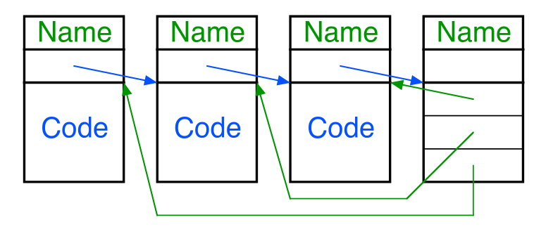

Mit anderen Worten: Threaded Code besteht im Grunde aus zwei verschiedenen "Code"-Stücken:

- Zwischencode
- Maschinencode

Der Maschinencode ist der "tatsächliche" Code der ausgeführt wird. Das muss natürlich nicht klassisches (Dis-)assembly sein, sondern ein beliebiger Code der von einer gegebenen (abstrakten) Maschine ausgeführt werden kann.

Zwischencode ist lediglich für das managen des Maschinencodes zuständig. Auf Assembly-Ebene würde man hier zb eine Aneinanderreihung von jump instructions finden. Man kann sich das aber auch wie eine Main-Function vorstellen, die nacheinander function-calls macht.

Betrachtet man das Bild vom Skriptum, dann wären die ersten 3 Tabellen (mit `Code` geschrieben) die Maschinencode-Blöcke, und die 4te Tabelle enthält den Zwischencode-Block mit den Pointern zu den Maschinencode-Blöcken. Das wichtige Detail ist hier eben, dass die Maschinencode-Blöcke nichts voneinander wissen, sondern nur einen Pointer (`instruction counter` / `instruction pointer`) zurück auf den Zwischencode haben (genauer dann bei Threaded Code Arten beschrieben).

Es gibt jetzt aber mehrere Möglichkeiten, wie der Zwischencode und die "return logic" vom Maschinencode implementiert ist. Als simples Beispiel könnte der Zwischencode entweder wirklich eins nach dem anderen eine Funktion aufrufen, oder es gibt eine globale Liste mit einem index-counter welcher direkt nach jedem Function-Call sofort erhöht wird und somit kann die "return logic" vom Maschinen-Code selbst gleich den nächsten Maschinen-Code Block aufrufen.

Die Unterschiede hier geben dann je nach ISA und Microarch dann unterschiedlich gute performance.

Konkret unterscheiden wir zwischen diesen threaded code Arten:

- subroutine threaded code
- direct threaded code
- indirect threaded code
- token threaded code
- indirect token threaded code

## Threaded Code Arten

### subroutine threaded code

Die (meiner Meinung nach) einfachste Art von threaded code. Im Grunde genau die konkrete Abfolge von Function-Calls in einer main-function.

Auf Assembly-Ebene sieht das dann z. B. so aus:

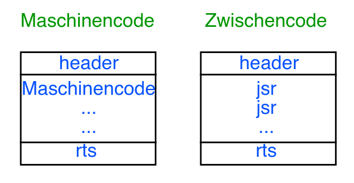

Wie man sieht enthält der Zwischencode also wirklich subroutine calls, und der Maschinencode macht am Ende einfach ein return, wodurch der Zwischencode automatisch den nächsten subroutine call dann macht.

### direct threaded code

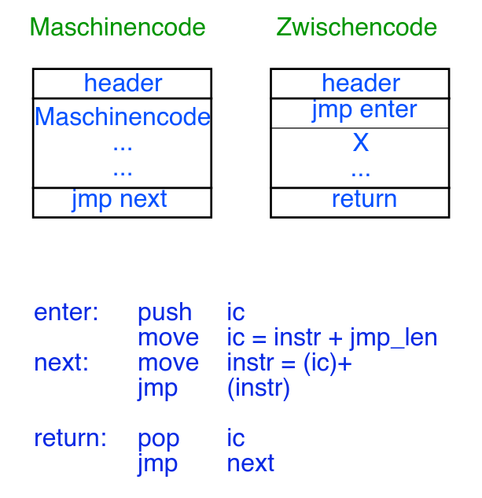

Beim direct threaded code springt man nicht mehr die ganze Zeit zwischen Maschinencode und Zwischencode hin und her. Der Zwischencode ist zwar noch immer der main entrypoint, aber enhält jetzt nur noch mehr eine Liste von Adressen / Pointern zu den einzelnen Maschinencode-Blöcken (also *keine* call instructions mehr).

Stattdessen wird jetzt am Anfang nur ein instruction-counter (ic) initialisiert (i.e. ein pointer zu der Address-Liste), welcher einfach am Anfang der Address-Liste beginnt. Nachdem der erste (oder ein beliebiger) Maschinencode-Block fertig ausgeführt wurde, steht am Ende von diesem ein `jmp next`. Schaut man sich im Bild den Pseudo-Assembly-Code an sieht man, dass hier einfach der `ic` incremented und dann auf die Addresse der nächsten instruction `instr` gesprungen wird `jmp (instr)`.

Das `push ic` und `pop ic` ist die exit-logic vom gesamten "Programm".

Hier auch ein Code-Beispiel von Wikipedia:

```c
#define PUSH(x) (*sp++ = (x))
#define POP() (*--sp)
start:
  ip = &thread  // ip points to &pushA (which points to the first instruction of pushA)
  jump *ip++  // send control to first instruction of pushA and advance ip to &pushB
thread:
  &pushA
  &pushB
  &add
  ...
pushA:
  PUSH(A)
  jump *ip++ // send control where ip says to (i.e. to pushB) and advance ip
pushB:
  PUSH(B)
  jump *ip++
add:
  result = POP() + POP()
  PUSH(result)
  jump *ip++
```

### indirect threaded code

Der Unterschied zwischen `direct` und `indirect` (unten dann auch bei `token`) threaded code ist, dass es eine weitere *Indirektion*, also ein extra Pointer gibt. Am besten vergleicht man den direct threaded code von oben mit den folgenden äquivalenten indirect threaded code:

```c
start:
  ip = &thread  // points to '&i_pushA'
  jump *(*ip)  // follow pointers to 1st instruction of 'push', DO NOT advance ip yet
thread:
  &i_pushA
  &i_pushB
  &i_add
  ...
i_pushA:
  &push
  &A
i_pushB:
  &push
  &B
i_add:
  &add
push:
  // look 1 past start of indirect block for operand address
  *sp++ = *(*ip + 1)
  // advance ip in thread, jump through next indirect block to next subroutine
  jump *(*++ip)
add:
  addend1 = *--sp
  addend2 = *--sp
  *sp++ = addend1 + addend2
  jump *(*++ip)
```

Man sieht, dass hier eine extra indirection ist (deswegen auch `jump *(*++ip)`, mit 2mal deref `*`). Performance ist dadurch natürlich zwangsweise schlechter als bei direct threaded code, da schließlich eine pointer-deref mehr berechnet werden muss.

Der Vorteil ist allerdings ein kompakterer Code: Wenn beispielsweise `push` eine Implementation von 10 Zeilen hätte, dann würde das beim **direct** threaded code insgesamt **20** Zeilen hinzufügen (2 * 10), bei **indirect** aber nur 10, da die Implementation "ausgelagert" wurde. Das funktioniert deswegen, da man jetzt Maschinencode selbst Parameter handeln kann, das sieht man z. B. bei `i_pushA`:

```c
i_pushA:
    &push
    &A
```

`&A` wird hier ausschließlich als Parameter für `push` verwendet. Da `&push` am Anfang von `i_pushA` steht, wird auch dorthin gesprungen: `*ip -> i_pushA, **ip -> *i_pushA -> push`. Bedeutet es wird nie (sinnvoller weise) auf die Adresse von `A` gesprungen, sondern nur in der Implementation von `push` dann selbst dereferenziert und als **Wert** (in dem Fall für den Stack) verwendet:

```c
push:
    *sp++ = *(*ip + 1)
```

`*ip + 1 -> i_pushA + 1 -> &A, *(*ip + 1) -> *(i_pushA + 1) -> *(&A) -> A`

### token threaded code

Im Grunde noch eine zweite Art von indirection. Jetzt geht es im Grunde um folgenden Fall:

```c
thread:
    &pushA
    &pushA
    &add
```

Als Lösung für dieses tragische Problem kann man also nun eine extra Tabelle erstellen, welche einfach alle Adressen aller verwendeten Funktionen auflistet. Greift man nun auf diese Tabelle per "index" zu, kann man sich demnach Platz sparen, jenachdem wie groß der Datentyp für den Index ist.

Bsp: Index hat 1bit Größe (i.e. 2 Einträge in der Tabelle möglich)

```c
thread:
    1
    1
    0

table:
    &add
    &pushA
```

Hiermit verbrauchen wir also nur noch mehr `(2 * 8) + (3 * 1) = 19bit < 3 byte`. Eine unfassbare `~20%` runtime code-size reduction.

Der Rest bleibt im Grunde gleich, ein vollständiges Bsp wäre:

```c
start:
  vpc = &thread
dispatch:
  // Convert the next bytecode operation
  // to a pointer to machine code that implements it
  addr = decode(&vpc)
  // Any inter-instruction operations are performed here
  // (e.g. updating global state, event processing, etc)
  jump addr
CODE_PTR decode(BYTE_CODE **p) {
  // In a more complex encoding,
  // there may be multiple tables to choose between or control/mode flags
  return table[*(*p)++];
}
thread:  /* Contains bytecode, not machine addresses.  Hence it is more compact. */
  1 /*pushA*/
  2 /*pushB*/
  0 /*add*/
table:
  &add    /* table[0] = address of machine code that implements bytecode 0 */
  &pushA  /* table[1] ... */
  &pushB  /* table[2] ... */
pushA:
  *sp++ = A
  jump dispatch
pushB:
  *sp++ = B
  jump dispatch
add:
  addend1 = *--sp
  addend2 = *--sp
  *sp++ = addend1 + addend2
  jump dispatch
```

Wir haben also noch immer einen instruction pointer, allerdings zeigt dieser jetzt nicht mehr auf "echte" Adressen, sondern auf Indexe `->` und diese können wir gemeinsam mit der Tabelle verwenden um dann doch den Pointer vom Maschinencode zu bekommen.

### indirect token threaded code

Einfach eine Kombination aus token threaded code und der vorherigen Beschreibung von `indirect` threaded code.

- `token` `->` Reduziert size beim referenzieren im call-thread
- `indirect` `->` Reduziert size indem Maschinencode nicht (weniger) dupliziert werden muss

## Threaded Code Vergleich

Äquivalenter Code kann auf die verschiedenen threading Arten compiled werden. Allerdings macht es ja einen Unterschied auf welcher MiA ein Code ausgeführt wird. Diese Unterschiede in der MiA können dann sogar dazu führen, dass derselbe Code mit zb:

- `direct threaded` **schneller** als `subroutine threaded` auf Maschine `A` ist, aber
- `direct threaded` **langsamer** als `subroutine threaded` auf Maschine `B` ist

Man kann daher nicht per-se sagen, welche Threading-Art schneller ist (mit Außname, dass indirect natürlich immer langsamer als direct threading ist).

# Forth

# Pascal P4

# JVM

# Microsoft IL

# Registermaschinen

# DalvikVM

# Syntaxgesteuerte Editoren

# Baummaschinen

## Prolog

Ein Program ist quasi wie ein Beweis. Eine fundamentale Datenstruktur ist die Liste. Diese wird mit `[]` dargestellt. Auf Listenelemente kann man mit `[Head|Tail]` zugreifen wobei `Head` das erste Element und `Tail` alle weiteren enthält.

#### Variablen

Werden EIMALIG an einen Wert gebunden. Schlägt ein Ast der Beweisführung/Programmausführung fehl, wird ein Backtracking betrieben und die Variablenbindungen zurückgesetzt.

#### Regeln

Regeln (auch Prozeduren genannt) werden so, als Fakten:

```
head(stat, stat).
```

oder so als Statements

```
head(stat, stat) :-
    body1(stat, stat),
    body2(stat, stat),
    bodyn(stat, stat).
```

definiert. Dabei müssen, damit im 2. Bsp. `head` bewiesen ist, alle Subgoals des bodies bewiesen werden.

### Ausführung

#### Resulution

Geht von oben nach unten, links nach rechts und versucht die Goals zu beweisen. (Ausführungsreihenfolge)

#### Unification

Bindet die freien Variablen. Generell liefert die Unifikation `true`, wenn für

- Konstanten beide den gleichen Wert besitzen.
- Strukturen beide den gleichen Namen, Arität haben und alle Argumente ebenfalls Unifizieren.
- freie Variablen keine Bedingung gilt. Liefert immer `true` und beide Variablen werden aneinander gebunden.
- eine Variable und eine Konstante/Struktur keine Bedingung gilt. Liefert immer `true` und die Konstante/Struktur wird an die Variable gebunden Wenn eine Struktur rekursiv ist kann man entweder `false` zurückgeben oder mit diesen "infinite terms" arbeiten.

##### Implementierung

Mithilfe von Pointern recht einfach realisierbar, in dem einfach dieser auf das jeweilige Objekt zeigt.

### Datenrepräsentation

Da Prolog dynamisch Getypt ist, muss für jedes Objekt ein Tupel von `(tag, value)` gespeichert werden. Prolog hat folgende Basistypen:

- atom (Zeichenketten)
- integer
- structure (terme mit namen, arität)
- unbound variable
- reference Strukturen werden als Liste dargestellt und Funktoren innerhalb dieser mit dem reference typ verknüpft. Eine etwas bessere Darstellung bekommt man mitilfe der "Tagged Pointer Darstellung", wo die Pointer z.B. einer `List` einen Tag ebensolchen Tag haben. Freie Variablen werden als Selbstreferenz dargestellt.

#### Datenbereiche

##### Environment stack

Die Abarbeitung der Resolution liefert einen Stack. Dieser Rerpäsentiert gleichzeitig den AND-OR-Tree des Beweises. Für jeden Aufrufs einer Regel wird ein neuer Stackframe angelegt.

##### Trail

Speichert die Adressen der Variablen die gebunden wurden. Resetted alle diese Variablen beim Backtracking.

##### Copy Stack (Heap)

Speichert die Strukturen.

#### Stackframes

##### Deterministischer Stackframe

Im Prinzip aufgebaut wie ein normaler Stackframe mit dynamic link (callers frame) und return address (callers goal).

##### Choicepoint

Speichert zusätzlich alternativen (in der Code area). Außerdem speichert er den state des trail und copy stacks um diese resetten zu können. Hat zusätzlich noch einen previous choice point (dynamic link).

### Optimierungen der Abstrakten Maschinen

##### Variablen Klassifikation

Variablen die nur ein mal in einer Regel vorkommen können nur geschrieben werden und somit eliminiert. Temporäre Variablen kommen nur in einem Subgoal vorkommen können in einem Register gehalten werden. Lokale Variablen werden im Stackframe gespeichert.

#### Last Call Optimization

Versucht Speicher zu sparen in dem Stackframes nach Möglichkeit übereinandergelegt werden.

## Warren Abstract Machine (WAM)

Ist aufgebaut wie die Implementierung einer Imperativen Programmiersprache (argument registers, parameter passing, etc). Hat genau so die Datenbereiche wie oben beschrieben. Hat allerdings noch ein paar zusätzliche Hilfsregister

- CP continuation program pointer (fungiert wie eine Rücksprungadresse/Link Register in RISC)
- B (backtrack point) der letze choice point
- TR top of trail
- A top of stack
- E frame pointer (environment pointer)
- H top of heap
- S current structure being unified

#### Instruktionen

Mit `put_value(Vn, Ri)` wird eine Variable in ein Register geschrieben (erstes Auftreten), ist eine Kopieroperation. Mit `get_variable(Vn, Ri)` wird eine Variable in ein Register geschrieben (weiteres Auftreten), ist die Unifikation Mit `unify_constant C` wird eine Konstante Unifiziert. (Falls Argumente einer Regel Strukturen sind) Hier wird unterschieden zwischen Read und Write Mode, da einmal mit einer Struktur unifiziert wird und einmal mit einer Freien Variable, was einem Assign gleichkommt. `call` funktioniert wie `call, ret`

#### Choicepoint

Speichert neben den Pointer Registern auch die Argument Register.

#### Binary Prolog

Hat nur ein Subgoal. Somit gibt es keine lokalen Variablen sondern nur temporäre. Ist eine Vereinfachte WAM.

## Vienna Abstract Machine (VAM)

Versucht das Paramter Passing bottleneck der WAM zu eliminieren. Es gibt:

- VAM_2p für interpreter
- VAM_1p für compiler
- VAM_ai für abstract interpretation (sammelt analyseinformation für VAM_1p)

### VAM_2p

Hat 2 Instruction Pointer. Einer für ein Subgoal, der andere für den Head. Dabei wir immer eine kombinierte instruktion sprich

```c
switch (*goalptr++ + *headptr++)
```

ausgeführt. Da man nun 2 IP hat hat man entsprechend nun jeweils 2 Pointer in die Code Area und den Envrionment stack, einen für `goal`, den anderen für `head`.

### VAM_1p

Kombiniert die beiden Instruktionen der VAM_2p zur compile Zeit.

### VAM_AI

Sammelt informationen zu Reference Chain Lengths (0, 1, >1) und Alias Information von Variablen.

# Funktionale Sprachen

## Symbolische Darstellung

In funktionalen Sprachen haben Tupel/Listen eine große Bedeutung. Als notation werden entweder Bäume, durch `,` separierte Listen `(A,B,C)` in Lisp-ähnlichen sprachen durch separierte Listen `((A B C) D (E F G))` oder durch die Dot-Notation die die Liste in Element und Restliste teilt dargestellt `(A.(B.C))`. Die Dot-Notation ist leicht zu implementieren, unterstützt aber pro Knoten immer nur zwei Kinder. In Implementierungen von Funktionalen sprachen ist sind vor allem zwei bezeichnungen für first/head/left und last/tail/right geläufig. `car` und `cdr`. Bsp: `car(cdr(cdr(l)))` stellt das 3. Element der Liste `l` dar.

## *λ*-Kalkül

Der Lambda-Kalkül ist eines der Einfachsten Programiersprachen. Es besteht nur aus Variablen `a, b, ..., z` und Funktionen der Gestalt *λ*`<args>.<body>` wo `<args>` Variablen und `<body>` eine Funktion oder Variablen sind. Als letztes gibt des noch die Anwendung einer Funktion auf eine Funktion oder Variablen: `(<func><args>)`. Zum Rechnen gibt es 3 Regeln:

1. *α*-Reduktion: *λ**u*.*e* ≡ *λ**v*.[*v*/*u*]*e* *v* ∉ *f**v*(*e*)
2. *β*-Reduktion: (*λ**v*.*f*)*e* ≡ [*e*/*v*]*f*
3. *η*-Reduktion: *λ**v*.(*e**v*) ≡ *e* *v* ∉ *f**v*(*e*)

#### Normalform

Ein lambda-Ausruck ist in Normalform wenn keine Beta- oder Etareduktion mehr angewandt werden kann.

#### Auswertungsreihenfolge

Es kann bei der Auswertung der Ausdrücke passieren, dass zu bestimmten Zeitpunkten unterschiedliche Reduktionen möglich sind. Dabei ist für das Endergebnis egal welcher Ausdruck zuerst reduziert wird. Allerdings können bestimmte Reduktionsreihenfolgen nie terminieren.

## Interpreter im Lambda-Kalkül

Die Frage die sich logischerweise mit der Möglichkeit einer Programmiersprache stellt ist, ob sie mächtig genug ist sich selbst als berechenbare Funktion zu beschreiben, dh. ob es möglich ist eine Funktion `eval()` zu schreiben die angewendet auf einen beliebigen Ausdruck `E` diesen so weit wie möglich reduziert und das Ergebnis retourniert. Dies ist in der tat möglich, außerdem gilt auch `eval(E) = eval(eval(E))`.

## Die SECD Abstrakte Maschine

### Speicher

Nachdem Funktionale Sprachen stark auf Listen aufbauen macht es Sinn, das der Speicher ebenfalls diese Datenstruktur unterstützt. Dabei wird der Speicher in Zellen unterteilt, die jeweils aus einer fixen Anzahl an Speicher Bits bestehen. Jede Zelle ist außerdem eindeutig addressierbar. Ein Tag beschreibt wie die Zelle zu interpretieren ist, dh. ob die Zelle ein Nonterminal `cons` oder ein Terminal zb `integer` darstellt. Für `cons` Zellen ist somit der Speicherbereich in die Felder `car` und `cdr` aufgeteilt. Ein Pointer mit dem Wert`0 (NIL)` ist ungültig und somit nicht als Adresse nutzbar.

### Register

#### S-Register (Stack Register)

Das S-Register zeigt auf eine Liste im Speicher die wie ein Stack agiert, allerdings als Linked-List implementiert ist. Wird also etwas vom Stack gepoppt und gepushed verbleibt der alte Wert als Garbage im Speicher und muss von einem GC eingesammelt werden sollte er nicht mehr gebraucht werden. Der Stack wird vor allem für `built-in` Funktionen wie `+ - h x/ car cdr` genutzt.

#### E-Register (Environment Register)

Das E-Regitser zeigt auf eine Liste der Argumente der aktuellen Funktion.

#### C-Register (Control Pointer)

Hat das gleiche verhalten wie ein Program Counter in einem Computer. Zeigt auf die nächste auszuführende Instruktion.

#### D-Register (Dump Register)

Zeigt auf eine Liste namens dump. Der dump hat die Aufgabe den Zustand einer Funktion zu Speichern wenn innerhalb der Funktion noch eine Funktion aufgerufen wird. Das wird erreicht in dem der Inhalt des S, E und C Registers auf diesen dump/stack geschrieben wird und diese nach der Beeindigung der Funktion wieder in die entsprechenden Register gepoppt werden.

### Instruktionen

Instruktionen sind einfache Integer Werte meist ohne Argumente. (Byte Code ähnlich) Sie manipulieren die Register in eine vorgegebene Art und Weise. Dabei gibt es zirka 6 Gruppen an Instruktionen:

1. Werte/Objekte auf den S Stack schreiben
2. Builtin Auswertungen auf dem S Stack durchführen.
3. If-then-else Behandlung
4. Non-Rekursive Funktionsbehandlung/Aufrufe
5. Rekursive Funktionsbehandlung
6. I/O Die ersten zwei Kategorien funktionieren wie in einem normalen Computer auch.

##### If-then-else

ITE hingegen braucht etwas speziellere Behandlung. Hierfür gibt es zwei Instruktionen `SEL` und `JOIN`. `SEL` schaut auf den obersten Wert am Stack und schaut ob dieser 0 ist oder nicht (boolean). Anschließend wird entweder der nächste Wert in der Instruktionsliste (C-Register) dorthin geladen oder der Else Block genommen und der Übernächste wert in das C-Register geschrieben. Außerdem wird der `cdr` dieses else Zweigs auf den Stack gepushed um später mithilfe eines `JOIN` wieder in das C-Register gepoppt werden zu können. Beispielsweise wird `if null(x) then 10 else -10` als Codeliste zu `(NULL SEL (LDC 10 JOIN)(LDC -10 JOIN))` übersetzt.

##### Nicht-rekursive Funktionen

Bestehen aus einer Liste von Argumenten, dem `LDF (load function)` befehl, dem Function Body, wobei der letzte Befehl des Body ein `RTN` sein muss und dem `AP (apply)` Befehl. Im allgemeinen wird eine Funktion erst mit einem `AP` ausgewertet. Dafür müssen allerdings zuerst die Argumente dieser Funktion ausgewertet werden. `AP` pushed cddr(S), E und cdr(C) auf den dump, setzt S auf `NIL`. C wird auf den Anfang des Function-body gesetzt. E wird auf `cons` des zweiten Element des ursprünglichen Stacks und `cdr` des Funktion bodies (eigentlich das Environment welches die Funktion selbst braucht) gesetzt. Wird nun ein `RTN` aufgerufen werden E und C direkt von dem Stack gepoppt und S wird der Pointer zu `cons` von dem alten S und dem Wert am Stack welcher das Ergebnis der Funktion repräsentiert.